```r
# I load the needed libraries
library(dplyr)
library(ggplot2)
```

# Exercise 1

Study the binomial inference for a study that reports y = 7 successes in n = 20 independent trial. Assume the following priors:

- a uniform distribution
- a Jeffrey’s prior
- a step function:

$$ g(π) = \begin{equation*} \begin{cases} \pi \hspace{14 mm} \text{if} \hspace{5 mm} \pi ≤ 0.2 \\ 0.2 \hspace{12 mm} \text{if} \hspace{5 mm} 0.2 < \pi ≤ 0.3 \\ 0.5 − \pi \hspace{6 mm} \text{if} \hspace{5 mm} 0.3 < \pi ≤ 0.5 \\ 0 \hspace{15 mm} \text{if} \hspace{5 mm} 0.5 < \pi \end{cases} \end{equation*} $$

- plot the posterior distribution and summarize the results computing the first two moments
- compute a 95% credibility interval and give the results in a summary table
- draw the limits on the plot of the posterior distribution

Since I know that the likelihood is a binomial distribution (due to the logic of the experiment), I only have to change the prior and look for the posterior in the three asked cases, where I know from the theory that:

- For the uniform distribution the posterior is the same function as the likelihood
- For a beta prior (with special case for the Jeffrey distribution) a beta posterior is obtained
- For the ste punction, there is the need of performing numerical calculations

```
The first moment is 0.3636364
The second moment is 0.03986908
```

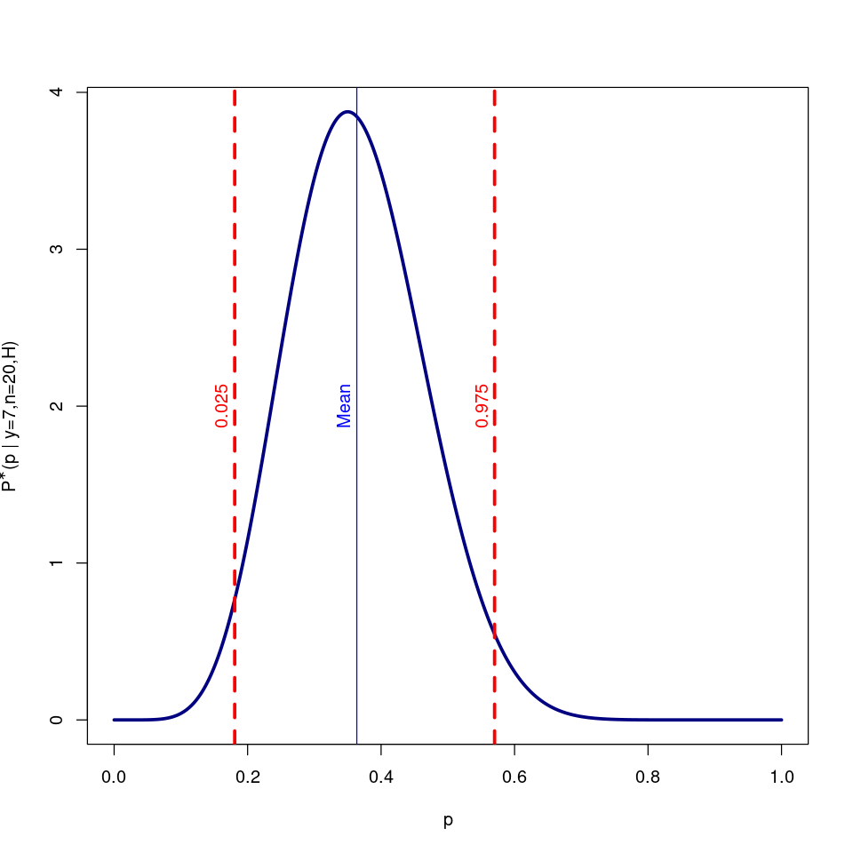

```r
# Uniform prior means that the posterior is a binomial
n = 20
y = 7
N = 1000

# Parameters to perfor the evaluation
ci = 0.95

# I generate a sequence of probabilities in the range [0, 1)
p = seq(0, 1, length.out=N)
uniform_posterior = dbinom(x=y, size=n, prob=p)
integral = sum(uniform_posterior)/N
# That has to be normalized
uniform_posterior = uniform_posterior/integral

# And then evaluate the first two moments (algebraic first moment and central second moment)
uniform_first_moment = sum(p*uniform_posterior)/N
cat("The first moment is", uniform_first_moment, "\n")

uniform_second_moment = sum(p*(uniform_posterior-uniform_first_moment)**2)/n/N
cat("The second moment is", uniform_second_moment, "\n")

# The 95% credibility interval is therefore:
ci_interval = c((1-ci)/2, ci + (1-ci)/2)
cdf = 0; uniform_ci = double(2); non_entrato=TRUE
for (i in length(p):1){
    cdf = cdf + uniform_posterior[i]/N
    if (cdf < ci_interval[1]){
        uniform_ci[1] = (p[i-1] + p[i])/2
    }
    if (cdf > ci_interval[2] & non_entrato) {
        non_entrato= FALSE
        uniform_ci[2] = (p[i-1] + p[i])/2
    }
}

# And then I plot the distribution, with the highlighted credibility interval
eps = 0.02
options(repr.plot.width=8, repr.plot.height=8)
plot(p, uniform_posterior, col='navy', type='l', lty=1, lwd=3, xlab="p", ylab= expression (paste(P^symbol("*"), "(p | y=7,n=20,H)")))
abline(v=c(uniform_first_moment, uniform_ci[1], uniform_ci[2]), col=c("blue", "red", "red"), lty=c(1,2,2), lwd=c(1,3,3))
text(x=c(uniform_first_moment-eps, uniform_ci[1]-eps, uniform_ci[2]-eps),
    y=c(2, 2, 2), srt=90, c('Mean', as.character(ci_interval[2]), as.character(ci_interval[1])),
    col=c("blue", "red", "red"))
```

```
The first moment is 0.3571429
The second moment is 0.03835508
```

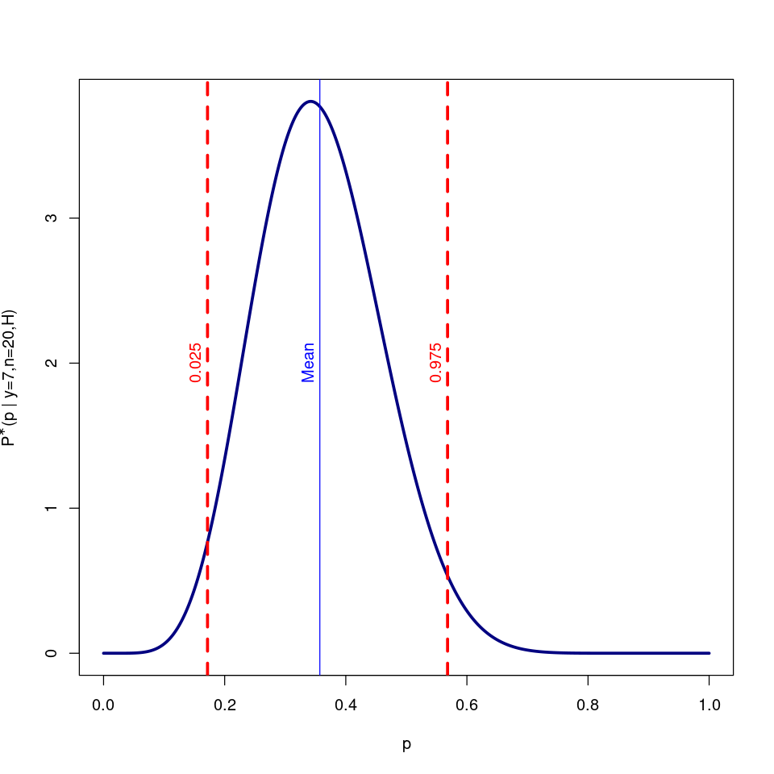

```r
# Beta prior (with parameters a, b) means that the posterior is a beta with parameters a'=a+y, b'=b+n-y, where n=20 and y=7 in our case

# Parameters of the jeffrey's distribution are
a=0.5; b=0.5

# I generate a sequence of probabilities in the range [0, 1) as done in the previous case
beta_posterior = dbeta(x=p, shape1=a+y, shape2=b+n-y)
integral = sum(beta_posterior)/N
# That has to be normalized
beta_posterior = beta_posterior/integral

# And then evaluate the first two moments (algebraic first moment and central second moment)
beta_first_moment = sum(p*beta_posterior)/N
cat("The first moment is", beta_first_moment, "\n")

beta_second_moment = sum(p*(beta_posterior-beta_first_moment)**2)/n/N
cat("The second moment is", beta_second_moment, "\n")

# In order to perform the evaluation of the confidence interval
cdf = 0; beta_ci = double(2); non_entrato=TRUE
for (i in length(p):1){
    cdf = cdf + beta_posterior[i]/N
    if (cdf < ci_interval[1]){
        beta_ci[1] = (p[i-1] + p[i])/2
    }
    if (cdf > ci_interval[2] & non_entrato) {
        non_entrato= FALSE
        beta_ci[2] = (p[i-1] + p[i])/2
    }
}

# And then I plot the distribution, with the highlighted credibility interval
plot(p, beta_posterior, col='navy', type='l', lty=1, lwd=3, xlab="p", ylab= expression (paste(P^symbol("*"), "(p | y=7,n=20,H)")))
abline(v=c(beta_first_moment, beta_ci[1], beta_ci[2]), col=c("blue", "red", "red"), lty=c(1,2,2), lwd=c(1,3,3))
text(x=c(beta_first_moment-eps, beta_ci[1]-eps, beta_ci[2]-eps), y=c(2, 2, 2), srt=90, c('Mean', as.character(ci_interval[2]), as.character(ci_interval[1])),
    col=c("blue", "red", "red"))

# One can easily see that this posterior is very similar to the previous one
```

```
The first moment is 0.3120456
The second moment is 0.05354603
```

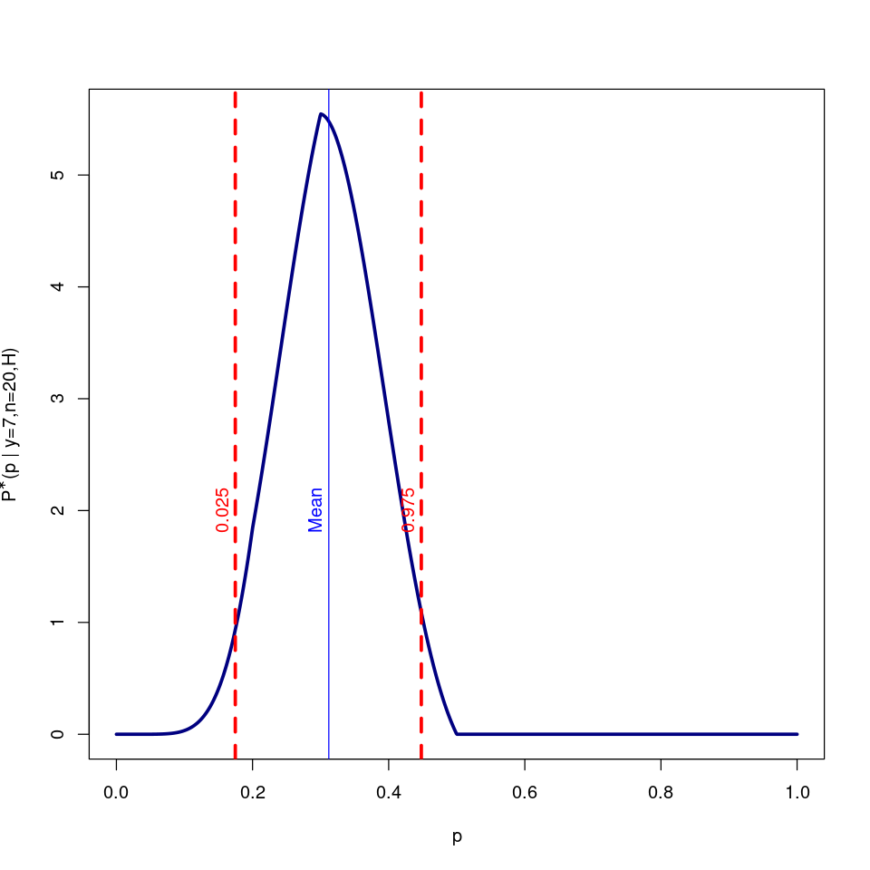

```r
# Beta prior (with parameters a, b) means that the posterior is a beta with parameters a'=a+y, b'=b+n-y, where n=20 and y=7 in our case

# I create a function as defined in the text
g = function(k) {
    out = 0
    if (k<=0.2) {
        out = k
    } else if (k<=0.3) {
        out = 0.2
    } else if (k<=0.5) {
        out = 0.5-k
    }
    return(out)
}

# I generate a sequence of probabilities in the range [0, 1) as done in the previous case
binom_likelihood = dbinom(x=y, size=n, prob=p)
step_posterior = double(length=length(p))
for (i in 1:length(p)) {
    step_posterior[i] = binom_likelihood[i] * g(p[i])
}

integral = sum(step_posterior)/N
# That has to be normalized
step_posterior = step_posterior/integral

# And then evaluate the first two moments (algebraic first moment and central second moment)
step_first_moment = sum(p*step_posterior)/N
cat("The first moment is", step_first_moment, "\n")

step_second_moment = sum(p*(step_posterior-step_first_moment)**2)/n/N
cat("The second moment is", step_second_moment, "\n")

# In order to perform the evaluation of the confidence interval
cdf = 0; step_ci = double(2); non_entrato=TRUE
for (i in length(p):1){
    cdf = cdf + step_posterior[i]/N
    if (cdf < ci_interval[1]){
        step_ci[1] = (p[i-1] + p[i])/2
    }
    if (cdf > ci_interval[2] & non_entrato) {
        non_entrato= FALSE
        step_ci[2] = (p[i-1] + p[i])/2
    }
}

# And then I plot the distribution, with the highlighted credibility interval
plot(p, step_posterior, col='navy', type='l', lty=1, lwd=3, xlab="p", ylab= expression (paste(P^symbol("*"), "(p | y=7,n=20,H)")))
abline(v=c(step_first_moment, step_ci[1], step_ci[2]), col=c("blue", "red", "red"), lty=c(1,2,2), lwd=c(1,3,3))
text(x=c(step_first_moment-eps, step_ci[1]-eps, step_ci[2]-eps), y=c(2, 2, 2), srt=90, c('Mean', as.character(ci_interval[2]), as.character(ci_interval[1])),
    col=c("blue", "red", "red"))
```

```r
# Summarizing the results in a table:
row1 = c("Uniform", "Binomial", uniform_first_moment, sqrt(uniform_second_moment), uniform_ci[1], uniform_ci[2])
row2 = c("Beta", "Beta", beta_first_moment, sqrt(beta_second_moment), beta_ci[1], beta_ci[2])
row3 = c("Step function", "Integral", step_first_moment, sqrt(step_second_moment), step_ci[1], step_ci[2])

table = matrix(c(row1, row2, row3), nrow=3, byrow=TRUE)
colnames(table) <- c('Prior','Posterior','Mean', 'Error', 'CI_low', 'CI_up')
table = as.data.frame(table, )
table[,c('Mean', 'Error', 'CI_low', 'CI_up')] = sapply(table[,c('Mean', 'Error', 'CI_low', 'CI_up')], as.numeric)

table
```

A data.frame: 3 × 6

| Prior <chr> | Posterior <chr> | Mean <dbl> | Error <dbl> | CI_low <dbl> | CI_up <dbl> |
| --- | --- | --- | --- | --- | --- |
| Uniform | Binomial | 0.3636364 | 0.1996724 | 0.5700701 | 0.1806807 |
| Beta | Beta | 0.3571429 | 0.1958445 | 0.5680681 | 0.1716717 |
| Step function | Integral | 0.3120456 | 0.2314002 | 0.4479479 | 0.1746747 |

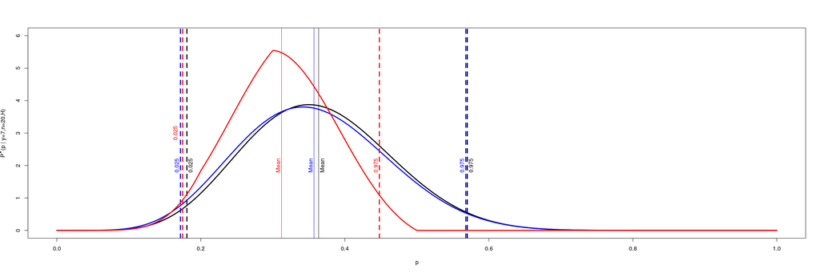

```r
# For a better visualization of these results, it is better to perform a plot
eps = 0.005
options(repr.plot.width=24, repr.plot.height=8)

plot(p, uniform_posterior, col='black', type='l', lty=1, lwd=3, xlab="p", ylab= expression (paste(P^symbol("*"), "(p | y=7,n=20,H)")), ylim=c(0, 6))
abline(v=c(uniform_first_moment, uniform_ci[1], uniform_ci[2]), col=c("black", "black", "black"), lty=c(1,2,2), lwd=c(1,3,3))
text(x=c(uniform_first_moment+eps, uniform_ci[1]+eps, uniform_ci[2]+eps),
    y=c(2, 2, 2), srt=90, c('Mean', as.character(ci_interval[2]), as.character(ci_interval[1])),
    col=c("black", "black", "black"))


lines(p, beta_posterior, col='blue', type='l', lty=1, lwd=3)
abline(v=c(beta_first_moment, beta_ci[1], beta_ci[2]), col=c("blue", "blue", "blue"), lty=c(1,2,2), lwd=c(1,3,3))
text(x=c(beta_first_moment-eps, beta_ci[1]-eps, beta_ci[2]-eps),
    y=c(2, 2, 2), srt=90, c('Mean', as.character(ci_interval[2]), as.character(ci_interval[1])),
    col=c("blue", "blue", "blue"))


lines(p, step_posterior, col='red', type='l', lty=1, lwd=3)
abline(v=c(step_first_moment, step_ci[1], step_ci[2]), col=c("red", "red", "red"), lty=c(1,2,2), lwd=c(1,3,3))
text(x=c(step_first_moment-eps, step_ci[1]-eps, step_ci[2]-2*eps),
    y=c(2, 2, 3), srt=90, c('Mean', as.character(ci_interval[2]), as.character(ci_interval[1])),
    col=c("red", "red", "red"))
```

# Exercise 2

Giardia cysts is a parassite that can contaminate food, water, and surfaces, and they can cause giardiasis when swallowed in this infective stage of their life cycle. Infection occurs when a person swallows Giardia cysts from contaminated water, food, hands, surfaces, or objects.

A group of researchers, working for a Human Health Department, work for determining the quality of stream water

- they take n = 116 samples of one-liter water from sites identified to have a heavy environmental impact from birds and waterflow
- out of these samples, y = 17 samples contained Giard cystis
- assuming π as the probability that one-liter water sample contains Giardia cystis, find the posterior distribution for π in the two cases: assuming a uniform prior distribution and assuming a Beta (1, 4) prior
- plot the posterior distribution and summerize the results computing the first two moments
- find a normal approximation for the posterior $g (π ∣ y)$
- compute a 95% credibility interval both for the original posterior and for the normal approximation, giving the results in a summary table
- add the limits on the plot of the posterior distributions

```r
# I define the parameters relevant for the evaluation
n = 116
y = 17
N = 1000
ci = 0.95

# UNIFORM PRIOR (code identical to the one of the previous example)
# Since this is a bernoulli process, I have to keep in mind that the posterior is a binomial, given a uniform prior
p = seq(0, 1, length.out=N)
uniform_posterior = dbinom(x=y, size=n, prob=p)
integral = sum(uniform_posterior)/N
# That has to be normalized
uniform_posterior = uniform_posterior/integral

# And then evaluate the first two moments (algebraic first moment and central second moment)
uniform_first_moment = sum(p*uniform_posterior)/N
cat("The first moment is", uniform_first_moment, "\n")

uniform_second_moment = sum(p*(uniform_posterior-uniform_first_moment)**2)/n/N
cat("The second moment is", uniform_second_moment, "\n")

# The 95% credibility interval is therefore:
ci_interval = c((1-ci)/2, ci + (1-ci)/2)
cdf = 0; uniform_ci = double(2); non_entrato=TRUE
for (i in length(p):1){
    cdf = cdf + uniform_posterior[i]/N
    if (cdf < ci_interval[1]){
        uniform_ci[1] = (p[i-1] + p[i])/2
    }
    if (cdf > ci_interval[2] & non_entrato) {
        non_entrato= FALSE
        uniform_ci[2] = (p[i-1] + p[i])/2
    }
}
```

[output not shown]

```r
# BETA PRIOR (code identical to the one of the previous example)
# Parameters of the Beta distribution are
a=1; b=4

# I generate a sequence of probabilities in the range [0, 1) as done in the previous case
beta_posterior = dbeta(x=p, shape1=a+y, shape2=b+n-y)
integral = sum(beta_posterior)/N
# That has to be normalized
beta_posterior = beta_posterior/integral

# And then evaluate the first two moments (algebraic first moment and central second moment)
beta_first_moment = sum(p*beta_posterior)/N
cat("The first moment is", beta_first_moment, "\n")

beta_second_moment = sum(p*(beta_posterior-beta_first_moment)**2)/n/N
cat("The second moment is", beta_second_moment, "\n")

# In order to perform the evaluation of the confidence interval
cdf = 0; beta_ci = double(2); non_entrato=TRUE
for (i in length(p):1){
    cdf = cdf + beta_posterior[i]/N
    if (cdf < ci_interval[1]){
        beta_ci[1] = (p[i-1] + p[i])/2
    }
    if (cdf > ci_interval[2] & non_entrato) {
        non_entrato= FALSE
        beta_ci[2] = (p[i-1] + p[i])/2
    }
}
```

[output not shown]

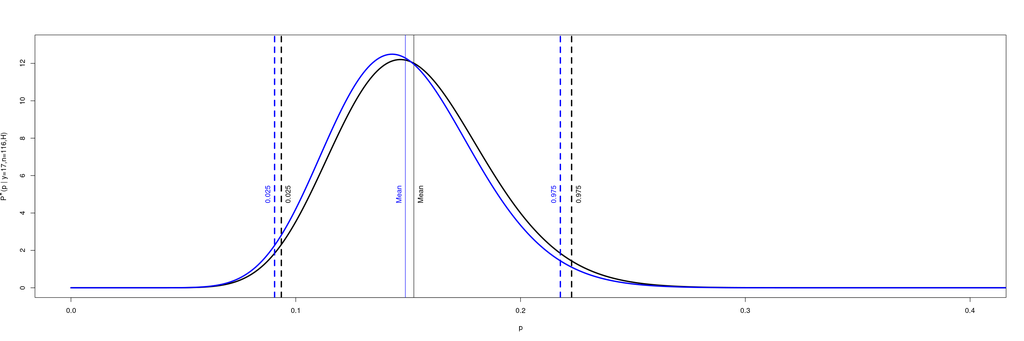

```r
# In order to show the results I plot the two distributions
eps = 0.003
options(repr.plot.width=24, repr.plot.height=8)

plot(p, uniform_posterior, col='black', type='l', lty=1, lwd=3, xlab="p", ylab= expression (paste(P^symbol("*"), "(p | y=17,n=116,H)")), xlim=c(0, 0.4),ylim=c(0, 13))
abline(v=c(uniform_first_moment, uniform_ci[1], uniform_ci[2]), col=c("black", "black", "black"), lty=c(1,2,2), lwd=c(1,3,3))
text(x=c(uniform_first_moment+eps, uniform_ci[1]+eps, uniform_ci[2]+eps),
    y=c(5, 5, 5), srt=90, c('Mean', as.character(ci_interval[2]), as.character(ci_interval[1])),
    col=c("black", "black", "black"))


lines(p, beta_posterior, col='blue', type='l', lty=1, lwd=3)
abline(v=c(beta_first_moment, beta_ci[1], beta_ci[2]), col=c("blue", "blue", "blue"), lty=c(1,2,2), lwd=c(1,3,3))
text(x=c(beta_first_moment-eps, beta_ci[1]-eps, beta_ci[2]-eps),
    y=c(5, 5, 5), srt=90, c('Mean', as.character(ci_interval[2]), as.character(ci_interval[1])),
    col=c("blue", "blue", "blue"))
```

```r
# Similarly to what done before, I create a table containing the results: both for mean, error and credibility interval
row1 = c("Uniform", "Binomial", uniform_first_moment, sqrt(uniform_second_moment), uniform_ci[1], uniform_ci[2])
row2 = c("Beta", "Beta", beta_first_moment, sqrt(beta_second_moment), beta_ci[1], beta_ci[2])

table = matrix(c(row1, row2), nrow=2, byrow=TRUE)
colnames(table) <- c('Prior','Posterior','Mean', 'Error', 'CI_low', 'CI_up')
table = as.data.frame(table)
table[,c('Mean', 'Error', 'CI_low', 'CI_up')] = sapply(table[,c('Mean', 'Error', 'CI_low', 'CI_up')], as.numeric)

table
```

A data.frame: 2 × 6

| Prior <chr> | Posterior <chr> | Mean <dbl> | Error <dbl> | CI_low <dbl> | CI_up <dbl> |
| --- | --- | --- | --- | --- | --- |
| Uniform | Binomial | 0.1525424 | 0.1041478 | 0.2227227 | 0.09359359 |
| Beta | Beta | 0.1487603 | 0.1040978 | 0.2177177 | 0.09059059 |

In order to perform a normal approximation, I have to present some theorical results. For a bernoulli process with uniform prior, the mean of the gaussiann is the mean of the distribution, and the standard deviation is given by the reliability, which is evaluated with the expression:

$$ \begin{equation} \sigma = \frac{1}{n}\sqrt{\frac{y(n-y)}{n}} \end{equation} $$

Similarly, for a beta posterior, the mean of the gaussiann is the mean of the distribution and the standard deviation is given by:

$$ \begin{equation} \sigma = \frac{1}{\alpha+\beta+n-2}\sqrt{\frac{\alpha+y-1}{\alpha+y}} \end{equation} $$

where $n, r$ are respectively the number of tosses and the number of positive outcomes and $\alpha, \beta$ are the parameters of the beta distribution

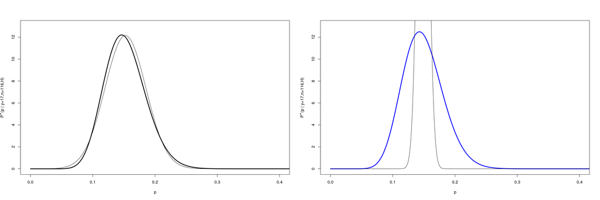

```r
# In order to find a normal approximation, I have to perform a

par(mfrow=c(1,2))

uniform_sd = sqrt(y*(n-y)/n)/n
uniform_gauss = dnorm(p, mean=uniform_first_moment, sd=uniform_sd)
plot(p, uniform_posterior, col='black', type='l', lty=1, lwd=3, xlab="p", ylab= expression (paste(P^symbol("*"), "(p | y=17,n=116,H)")), xlim=c(0, 0.4),ylim=c(0, 13))
lines(p, uniform_gauss)

# Since it is the posterior, I have to retrieve the parameters of the beta from the prior:
alpha=a+y; beta=b+n-y
beta_sd = sqrt((a+y-1)/(a+y))/(a+b+n-2)
beta_gauss = dnorm(p, mean=beta_first_moment, sd=beta_sd)
plot(p, beta_posterior, col='blue', type='l', lty=1, lwd=3, xlab="p", ylab= expression (paste(P^symbol("*"), "(p | y=17,n=116,H)")), xlim=c(0, 0.4),ylim=c(0, 13))
lines(p, beta_gauss)
```

# Exercise 3

A coin is flipped n = 30 times with the following outcomes: T, T, T, T, T, H, T, T, H, H, T, T, H, H, H, T, H, T, H, T, H, H, T, H, T, H, T, H, H, H

- Assuming a flat prior, and a beta prior, plot the likelihood, prior and posterior distributions for the

data set.

- Evaluate the most probable value for the coin probability p and, integrating the posterior probability

distribution, give an estimate for a 95% credibility interval.

- Repeat the same analysis assuming a sequential analysis of the data 1. Show how the most probable

value and the credibility interval change as a function of the number of coin tosses (i.e. from 1 to 30).

- Do you get a different result, by analyzing the data sequentially with respect to a one-step analysis

(i.e. considering all the data as a whole) ?

```r
# First I determine the number of tosses and of positive outcomes
T=FALSE; H=TRUE
tosses = c(T, T, T, T, T, H, T, T, H, H, T, T, H, H, H, T, H, T, H, T, H, H, T, H, T, H, T, H, H, H)

n = length(tosses)
y = sum(tosses)

N = 2000
ci = 0.95
```

```r
# Since now I will recall the same function 30 times (to retrieve the most probable value and credibility interval) I create the two functions:
normalize = function (distribution, N) {
    integral = sum(distribution)/N
    distribution = distribution/integral
    return(distribution)
}

moments = function (p, posterior, N, n) {
    first_moment = sum(p*posterior)/N
    second_moment = sum(p*(posterior-first_moment)**2)/n/N
    return(c(first_moment, second_moment))
}

ci_interval = function (p, posterior, ci_int, N) {
    ci_interval = c((1-ci_int)/2, ci + (1-ci_int)/2)
    cdf = 0; posterior_ci = c(1, 0); non_entrato=TRUE
    for (i in length(p):2){
        cdf = cdf + posterior[i]/N
        if (cdf < ci_interval[1]){
            posterior_ci[1] = (p[i-1] + p[i])/2
        }
        if (cdf > ci_interval[2] & non_entrato) {
            non_entrato= FALSE
            posterior_ci[2] = (p[i-1] + p[i])/2
            break
        }
    }
    return(c(posterior_ci[1], posterior_ci[2]))
}
```

```
The mean of the uniform posterior is 0.5
The confidence interval is [ 0.3304152 0.6695848 ]
```

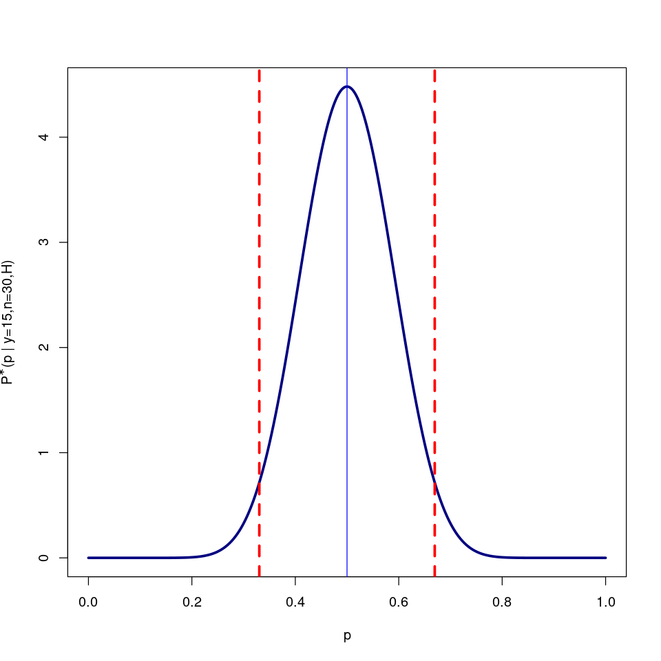

```r
# UNIFORM PRIOR
# For the uniform prior and a Bernoulli process, I know from theory that the posterior is a binomial: I do the same process described in the previous two examples

p = seq(0, 1, length.out=N)
uniform_posterior = dbinom(x=15, size=30, prob=p)
uniform_posterior = normalize(uniform_posterior, N)

uniform_moments = moments(p, uniform_posterior, N, n)
uniform_ci = ci_interval(p, uniform_posterior, ci, N)

cat("The mean of the uniform posterior is", uniform_moments[1], "\nThe confidence interval is [", uniform_ci[2], uniform_ci[1], "]\n")

options(repr.plot.width=8, repr.plot.height=8)
plot(p, uniform_posterior, col='navy', type='l', lty=1, lwd=3, xlab="p", ylab= expression (paste(P^symbol("*"), "(p | y=15,n=30,H)")))
abline(v=c(uniform_moments[1], uniform_ci[1], uniform_ci[2]), col=c("blue", "red", "red"), lty=c(1,2,2), lwd=c(1,3,3))
```

```
The mean of the beta posterior is 0.5
The confidence interval is [ 0.327914 0.672086 ]
```

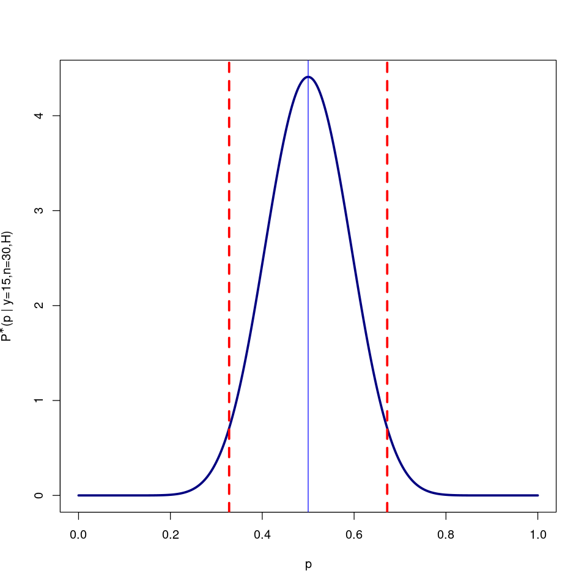

```r
# BETA PRIOR
# For the beta prior and a Bernoulli process, I know from theory that the posterior is a beta with changed parameters.
# I do the same process described in the previous two examples

# I select the values of the beta prior as the Jeffrey's parameters:
a=0.5; b=0.5
beta_posterior = dbeta(x=p, shape1=a+y, shape2=b+n-y)
beta_posterior = normalize(beta_posterior, N)

beta_moments = moments(p, beta_posterior, N, n)
beta_ci = ci_interval(p, beta_posterior, ci, N)

cat("The mean of the beta posterior is", beta_moments[1], "\nThe confidence interval is [", beta_ci[2], beta_ci[1], "]\n")

plot(p, beta_posterior, col='navy', type='l', lty=1, lwd=3, xlab="p", ylab= expression (paste(P^symbol("*"), "(p | y=15,n=30,H)")))
abline(v=c(beta_moments[1], beta_ci[1], beta_ci[2]), col=c("blue", "red", "red"), lty=c(1,2,2), lwd=c(1,3,3))
```

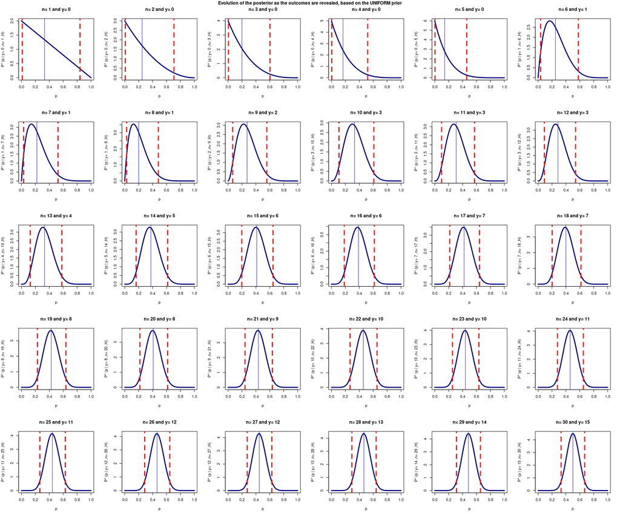

```r
# I create a loop for the extractions and I want to retrieve the evolution of the mean and the credibility interval
# CASE UNIFORM PRIOR
par(mfrow=c(5,6))
options(repr.plot.width=18, repr.plot.height=15)

uniform_means = double(length(tosses))
uniform_interval_low = double(length(tosses))
uniform_interval_high = double(length(tosses))

for (i in 1:length(tosses)) {
    relevant_tosses = tosses[(1:i)]
    n = length(relevant_tosses)
    y = sum(relevant_tosses)

    p = seq(0, 1, length.out=N)
    uniform_posterior = dbinom(x=y, size=n, prob=p)
    uniform_posterior = normalize(uniform_posterior, N)

    uniform_moments = moments(p, uniform_posterior, N, n)
    uniform_ci = ci_interval(p, uniform_posterior, ci, N)
    uniform_means[i] = uniform_moments[1]
    uniform_interval_low[i] = uniform_ci[1]; uniform_interval_high[i] = uniform_ci[2]

    title = paste("n=", n, "and y=", y)
    plot(p, uniform_posterior, col='navy', type='l', lty=1, lwd=3, xlab="p", ylab=paste("P*", "(p | y=", y, ",n=", n, ",H)"), main=title)
    abline(v=c(uniform_moments[1], uniform_ci[1], uniform_ci[2]), col=c("blue", "red", "red"), lty=c(1,2,2), lwd=c(1,3,3))
}
title("Evolution of the posterior as the outcomes are revealed, based on the UNIFORM prior",line=-1,outer=TRUE)
```

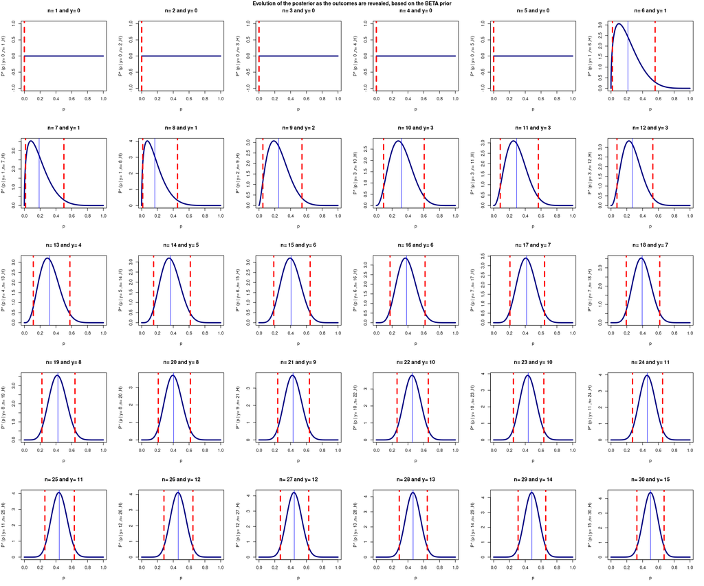

```r
# I create a loop for the extractions and I want to retrieve the evolution of the mean and the credibility interval
# CASE BETA PRIOR
par(mfrow=c(5,6))
a=0.5; b=0.5

beta_means = double(length(tosses))
beta_interval_low = double(length(tosses))
beta_interval_high = double(length(tosses))

for (i in 1:length(tosses)) {
    relevant_tosses = tosses[(1:i)]
    n = length(relevant_tosses)
    y = sum(relevant_tosses)

    p = seq(0, 1, length.out=N)
    beta_posterior = dbeta(x=p, shape1=a+y, shape2=b+n-y)
    beta_posterior = normalize(beta_posterior, N)

    beta_moments = moments(p, beta_posterior, N, n)
    beta_ci = ci_interval(p, beta_posterior, ci, N)
    if (is.nan(beta_moments[1])) beta_means[i] = 0 else beta_means[i] = beta_moments[1]
    beta_interval_low[i] = beta_ci[1]; beta_interval_high[i] = beta_ci[2]

    title = paste("n=", n, "and y=", y)
    plot(p, beta_posterior, col='navy', type='l', lty=1, lwd=3, xlab="p", ylab=paste("P*", "(p | y=", y, ",n=", n, ",H)"), main=title)
    abline(v=c(beta_moments[1], beta_ci[1], beta_ci[2]), col=c("blue", "red", "red"), lty=c(1,2,2), lwd=c(1,3,3))
}
title("Evolution of the posterior as the outcomes are revealed, based on the BETA prior",line=-1,outer=TRUE)
```

As a conclusion of the exercise, I can say that the two posterior distributions are strongly dependent on the number of extractions. In fact, up to the fifth extraction, most probable result for the probability $\pi$ was very near to zero. As the number of tosses grows, we see that the result tends to the expected value for a fair coin. I plot also the evolution of the expected value and the credibility interval in order to prove the previous sentence

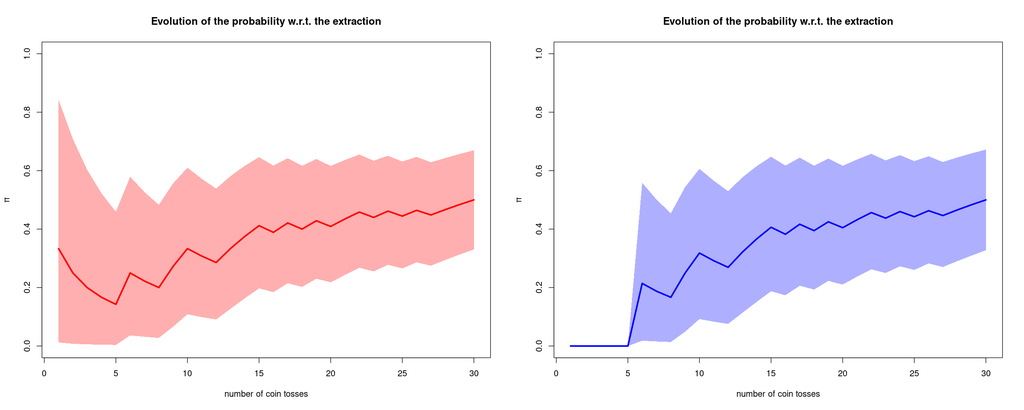

```r
# I only have to take the two filled vectors:
par(mfrow=c(1,2))
options(repr.plot.width=20, repr.plot.height=8)


plot(1:n, uniform_means, type="l", lwd=3, ylim=c(0, 1), xlab="number of coin tosses", ylab="π", col="red", main="Evolution of the probability w.r.t. the extraction")
polygon(c(1:n, n:1), c(uniform_interval_high, rev(uniform_interval_low)), col="#ff000050", border=NA)
plot(1:n, beta_means, type="l", lwd=3, ylim=c(0, 1), xlab="number of coin tosses", ylab="π", col="blue", main="Evolution of the probability w.r.t. the extraction")
polygon(c(1:n, n:1), c(beta_interval_high, rev(beta_interval_low)), col="#0000ff50", border=NA)
```

# Exercise 4 - Six Boxes Toy Model : inference

The six boxes toy model is described in reference: https://arxiv.org/pdf/1701.01143.pdf. Labeling the boxes as depending on the number of white stones contained within them: H0 H1 H2 H3 H4 H5, write a program in R that performs a simulation of the process:

- after selecting a random box
- make random sampling from the box
- prints on the standard output the probability of selecting each box
- plot the probability for each box as a function of the number of trial

```r
# The number of boxes is fixed at 6, wether the number of extractions is chosen to be 40
n_boxes = 6
n_extractions = 40  # number of extractions

# I select the box and then I extract randomly the stones according to the chosen box
box = floor(runif(1, min=0, max=n_boxes))
extraction = (floor(runif(n_extractions, min=0, max=n_boxes-1)) < box)

# NB: I encoded with TRUE the white stones and with FALSE the black ones
```

```r
# Now I initialize the probabilities for each box
probabilities = matrix(0, n_boxes, n_extractions+1)
probabilities[,1] = 1/n_boxes

# And then I implement the function able to perform the update of the probability for each extraction
for (i in 1:n_extractions) {
    if (extraction[i]) {
        probabilities[,i+1] = ((1:n_boxes)-1)*1/(n_boxes-1)*probabilities[,i]/sum(((1:n_boxes)-1)*1/(n_boxes-1)*probabilities[,i])
    } else {
        probabilities[,i+1] = (((n_boxes:1)-1)*1/(n_boxes-1))*probabilities[,i]/sum(((n_boxes:1)-1)*1/(n_boxes-1)*probabilities[,i])
    }
}

# Create data frame to show the evolution of the probabilities
prob_frame = as.data.frame(t(probabilities))
prob_frame = cbind(prob_frame[1:n_extractions,], extraction)
for (i in 1:n_extractions) {
    if (prob_frame$extraction[i]) prob_frame$extraction[i] = "White" else prob_frame$extraction[i] = "Black"
}

prob_frame
```

A data.frame: 40 × 7

|  | V1 <dbl> | V2 <dbl> | V3 <dbl> | V4 <dbl> | V5 <dbl> | V6 <dbl> | extraction <chr> |
| --- | --- | --- | --- | --- | --- | --- | --- |
| 1 | 0.1666667 | 0.1666667 | 0.16666667 | 1.666667e-01 | 1.666667e-01 | 0.1666667 | Black |
| 2 | 0.3333333 | 0.2666667 | 0.20000000 | 1.333333e-01 | 6.666667e-02 | 0.0000000 | Black |
| 3 | 0.4545455 | 0.2909091 | 0.16363636 | 7.272727e-02 | 1.818182e-02 | 0.0000000 | White |
| 4 | 0.0000000 | 0.3200000 | 0.36000000 | 2.400000e-01 | 8.000000e-02 | 0.0000000 | Black |
| 5 | 0.0000000 | 0.4383562 | 0.36986301 | 1.643836e-01 | 2.739726e-02 | 0.0000000 | White |
| 6 | 0.0000000 | 0.2461538 | 0.41538462 | 2.769231e-01 | 6.153846e-02 | 0.0000000 | Black |
| 7 | 0.0000000 | 0.3459459 | 0.43783784 | 1.945946e-01 | 2.162162e-02 | 0.0000000 | Black |
| 8 | 0.0000000 | 0.4452174 | 0.42260870 | 1.252174e-01 | 6.956522e-03 | 0.0000000 | Black |
| 9 | 0.0000000 | 0.5386639 | 0.38348238 | 7.574961e-02 | 2.104156e-03 | 0.0000000 | Black |
| 10 | 0.0000000 | 0.6229658 | 0.33262357 | 4.380228e-02 | 6.083650e-04 | 0.0000000 | Black |
| 11 | 0.0000000 | 0.6964506 | 0.27889479 | 2.448459e-02 | 1.700319e-04 | 0.0000000 | White |
| 12 | 0.0000000 | 0.5242880 | 0.41990400 | 5.529600e-02 | 5.120000e-04 | 0.0000000 | Black |
| 13 | 0.0000000 | 0.6047207 | 0.36324211 | 3.188957e-02 | 1.476369e-04 | 0.0000000 | Black |
| 14 | 0.0000000 | 0.6770773 | 0.30502880 | 1.785262e-02 | 4.132552e-05 | 0.0000000 | White |
| 15 | 0.0000000 | 0.5049582 | 0.45497554 | 3.994298e-02 | 1.232808e-04 | 0.0000000 | Black |
| 16 | 0.0000000 | 0.5829633 | 0.39394452 | 2.305665e-02 | 3.558125e-05 | 0.0000000 | Black |
| 17 | 0.0000000 | 0.6550452 | 0.33199106 | 1.295377e-02 | 9.995196e-06 | 0.0000000 | Black |
| 18 | 0.0000000 | 0.7194205 | 0.27346339 | 7.113410e-03 | 2.744371e-06 | 0.0000000 | Black |
| 19 | 0.0000000 | 0.7751746 | 0.22099233 | 3.832345e-03 | 7.392641e-07 | 0.0000000 | White |
| 20 | 0.0000000 | 0.6309110 | 0.35972924 | 9.357383e-03 | 2.406734e-06 | 0.0000000 | Black |
| 21 | 0.0000000 | 0.6968411 | 0.29799067 | 5.167614e-03 | 6.645594e-07 | 0.0000000 | White |
| 22 | 0.0000000 | 0.5326196 | 0.45552903 | 1.184936e-02 | 2.031782e-06 | 0.0000000 | Black |
| 23 | 0.0000000 | 0.6051178 | 0.38815048 | 6.731123e-03 | 5.770853e-07 | 0.0000000 | Black |
| 24 | 0.0000000 | 0.6726548 | 0.32360386 | 3.741191e-03 | 1.603734e-07 | 0.0000000 | White |
| 25 | 0.0000000 | 0.5053426 | 0.48622506 | 8.431886e-03 | 4.819322e-07 | 0.0000000 | Black |
| 26 | 0.0000000 | 0.5780447 | 0.41713264 | 4.822479e-03 | 1.378166e-07 | 0.0000000 | Black |
| 27 | 0.0000000 | 0.6470852 | 0.35021555 | 2.699233e-03 | 3.856928e-08 | 0.0000000 | Black |
| 28 | 0.0000000 | 0.7102269 | 0.28829182 | 1.481310e-03 | 1.058320e-08 | 0.0000000 | Black |
| 29 | 0.0000000 | 0.7660023 | 0.23319893 | 7.988200e-04 | 2.853581e-09 | 0.0000000 | Black |
| 30 | 0.0000000 | 0.8137698 | 0.18580584 | 4.243170e-04 | 7.578822e-10 | 0.0000000 | Black |
| 31 | 0.0000000 | 0.8536020 | 0.14617545 | 2.225432e-04 | 1.987447e-10 | 0.0000000 | Black |
| 32 | 0.0000000 | 0.8860814 | 0.11380306 | 1.155055e-04 | 5.157673e-11 | 0.0000000 | Black |
| 33 | 0.0000000 | 0.9120836 | 0.08785696 | 5.944749e-05 | 1.327256e-11 | 0.0000000 | Black |
| 34 | 0.0000000 | 0.9325951 | 0.06737456 | 3.039219e-05 | 3.392761e-12 | 0.0000000 | Black |
| 35 | 0.0000000 | 0.9485871 | 0.05139742 | 1.545668e-05 | 8.627350e-13 | 0.0000000 | White |
| 36 | 0.0000000 | 0.9021890 | 0.09776685 | 4.410194e-05 | 3.282145e-12 | 0.0000000 | Black |
| 37 | 0.0000000 | 0.9248135 | 0.07516393 | 2.260395e-05 | 8.411129e-13 | 0.0000000 | Black |
| 38 | 0.0000000 | 0.9425353 | 0.05745320 | 1.151855e-05 | 2.143077e-13 | 0.0000000 | White |
| 39 | 0.0000000 | 0.8913063 | 0.10866098 | 3.267747e-05 | 8.106384e-13 | 0.0000000 | Black |
| 40 | 0.0000000 | 0.9162104 | 0.08377281 | 1.679526e-05 | 2.083221e-13 | 0.0000000 | Black |

And now, in order to see the behaviour of the data, I plot the evolution of the data w.r.t. the extraction:

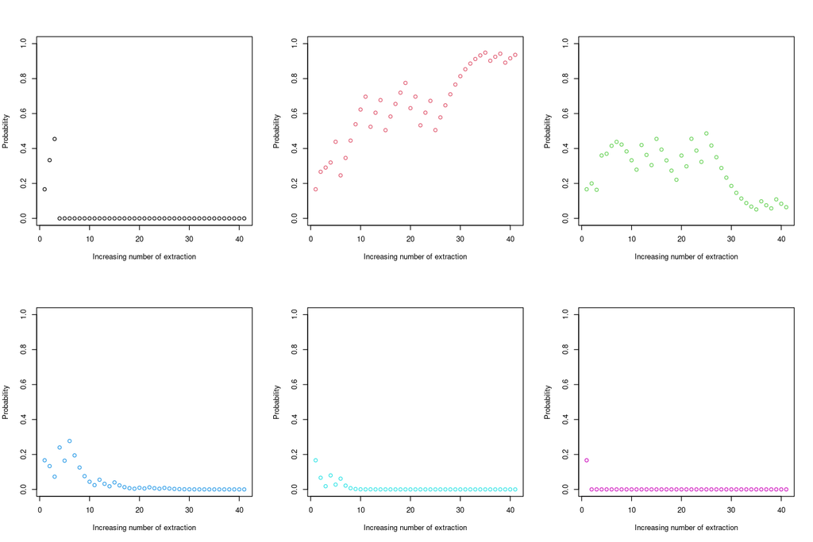

```r
# I plot the behaviour of the probability w.r.t. the extraction
par(mfrow=c(2,3))
options(repr.plot.width=12, repr.plot.height=8)

for (i in 1:n_boxes) {
    plot(1:(n_extractions+1), probabilities[i,], ylim=c(0, 1), xlab='Increasing number of extraction', ylab='Probability', col=i)
}
```